# Changes in allele and genotype frequency

## What to expect

In this section we will:

- explore the concept of Hardy Weinberg Equilibrium using R
- simulate genetic drift under the Hardy Weinberg expectation
- take a first look at how we can use R to program

## Introduction

Over the last two tutorials, we learned the basics of R and also how to manipulate, visualize and explore data. From this tutorial onwards, we will start change direction a little and reinforce some of the concepts of evolutionary genetics that you have been learning during the class sessions. This doesn’t mean we are going to throw you in at the deep-end and expect you to be completely relaxed in R, we will still take the opportunity to work through some of the concepts of the language we have already touched upon. Again remember, it is perfectly fine to ask for assistance or to look up R code you don’t understand - we use R everyday and turn to Google for solutions almost constantly!

For the bulk of this session, we will focus on exploring the **Hardy-Weinberg (HW) model** and testing for deviations from **Hardy-Weinberg Expectation (HWE)** using R code. You will recall that the HW-model is basically an idealized model of the relationship between allele and genotype frequencies, in the absence of the action of demographic processes such as inbreeding, and evolutionary processes such as genetic drift or selection. The model therefore acts as null model for testing whether such processes have taken place. In other words, we can compare our real data to the expectation and draw inference on what demographic or evolutionary processes might be acting in the real world. As well as allowing us to flex our R abilities, examining the HW-model also requires us to perform some basic statistical analysis, particularly a **goodness of fit** test.

In addition to the HW model and testing for deviations from HWE, we will also learn how to simulate **genetic drift** in R. Here we will make use of the visualisation skills we learned with `ggplot2` in [Chapter 2](https://markravinet.github.io/Chapter2.html) to recreate Figure 3.7 from the textbook. We hope that this will have the dual benefit of letting you play with population parameters in order to understand genetic drift but also to help you develop your R programming skills in more detail. During the course of this session we will encounter how to write `for` loops, learn about vectorization and also learn a little bit about how to write your own custom functions.

In this tutorial we will be exploring the Hardy-Weinberg model (HW-model). The model is used as a null hypotheses to investigate whether a population is affected by demographic or evolutionary processes. It simply states that a population is in HW-equilibrium if one is able to predict genotype frequencies from allele frequencies, or in other words: allele-and genotype frequencies remain constant in the subsequent generation.

## The Hardy-Weinberg Model

The HW model is a way of demonstrating the relationship between allele and genotype frequencies. It is mathematically basic but very important for understanding how different processes can alter these frequencies. As you might recall from the main text, the model has five major assumptions:

1. All individuals in the population mate randomly.
2. The population is infinitely large.
3. No selection occurs.
4. No mutation occurs.
5. No gene flow occurs.

Imagining our idealized population, we will focus on a single locus, $A$ which has two alleles, $A_1$ and $A_2$. We can use $p$ to denote the frequency of the $A_1$ allele and $q$ for $A_2$. This means that if we know $p$, we can derive $q$ as $q = 1- p$, since $p + q = 1$. Remember that the HW-model is a means of representing the relationship between allele and genotype frequencies across generations. With our assumptions outlined above in place, the only thing that determines the frequency of genotypes is their probabilities, derived from the allele frequencies.

It is quite simple to determine these probabilities. With 2 alleles $A_1$ and $A_2$, we have three possible genotypes and three ways to determine their probabilities as:

- $A_1A_1 = p^2$
- $A_1A_2 = 2pq$
- $A_2A_2 = q^2$

Another way to look at these probabilities is as the expected frequencies of the three genotypes at Hardy-Weinberg equilibrium given the allele frequencies. Let’s use some R code to actually demonstrate how we might calculate these expected frequencies. For our test example, we will use a simple case where the frequency of $A_1$, $p$ is 0.8 and the frequency of $A_2$, $q$ is 0.2.

```r
# first we set the frequencies
p <- 0.8
q <- 1 - p
# check p and q are equal to 1
(q + p) == 1
# calculate the expected genotype frequencies (_e denotes expected)
A1A1_e <- p^2
A1A2_e <- 2 * (p * q)
A2A2_e <- q^2
# show the allele frequencies in the console
c(A1A1_e, A1A2_e, A2A2_e)
# since these are genotype frequencies, they should also sum to 1 - you can check this like so
sum(c(A1A1_e, A1A2_e, A2A2_e))
```

So you can see it is quite easy to calculate the frequencies you need for the HW model in R. If you want to, you can play around with the initial frequencies defined at the start of the R code to see how it alters the genotype frequencies. This is one nice thing about using R for evolutionary genetics, it is pretty simple to demonstrate things mathematically to benefit your own understanding. However, it might be even more useful to demonstrate the relationships the HW model lays out graphically. That way you can see how the expected genotype frequencies are altered over a whole range of allele frequencies. Luckily for us, R is great for this sort of visualisation *and* this is an excellent opportunity to demonstrate some programming in R.

### Plotting the expected genotype frequencies

The first thing we need to do is generate a range of allele frequencies to visualize the expected genotype frequencies across. We’ll do this in the simplest way first, before going into how you might take a programming approach to the same problem. Either way, generating a range is simple - we just need to do it for a single allele, $A_1$ and then we can very easily derive the frequency of $A_2$. We will do this like so:

```r
# generate a range for p
p <- seq(0, 1, 0.01)
# and also for q
q <- 1 - p
```

All we did here was use the `seq` function, which we first saw back in [Chapter 1](https://markravinet.github.io/Introduction.html). Remember, we only have to do it once because $q$ is the inverse of $p$. Next we need to generate the expected frequencies. Because R is really great at handling vectors, the code for this is identical for if we were using a single value.

```r
# generate the expected genotype frequencies
A1A1_e <- p^2
A1A2_e <- 2 * (p * q)
A2A2_e <- q^2
```

So now we basically have the expected frequencies at HWE of our different genotypes across a range of allele frequencies with just a little vector calculation. However, recalling from before that we often need to get our data into a `data.frame` in order to use `ggplot2`, we need to do a bit of work on this first. We’ll now get our data into a `tibble` ready for working on…

```r
# arrange allele frequencies into a tibble/data.frame
geno_freq <- as.tibble(cbind(p, q, A1A1_e, A1A2_e, A2A2_e))
```

You also might remember from the previous session that we need to sometimes do some data manipulation to get the data into a form that we can easily plot. Luckily, this is quite straightforward in this case ad we can use the `gather` function to do it quickly and easily.

```r
# Use gather to reshape the data.frame for straightforward plotting
geno_freq <- gather(geno_freq, key = "genotype", value = "freq", -p, -q)
```

Now it is really straightforward to make a plot that shows the expected HW—frequencies across our allele frequencies.

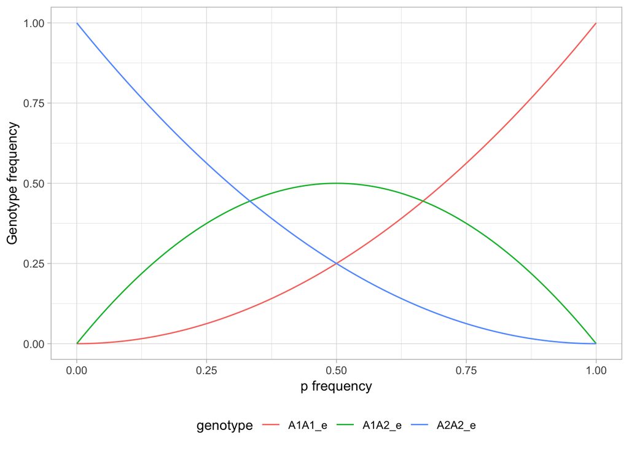

```r
# plot the expected genotype frequencies
a <- ggplot(geno_freq, aes(p, freq, colour = genotype)) + geom_line()
a <-a + ylab("Genotype frequency") + xlab("p frequency")
a + theme_light() + theme(legend.position = "bottom")
```

### Some programming tricks for the HW model

The example above, where we derived the expected frequencies of the HW-model took advantage of R’s ability to easily handle vectors. In principle, this is the simplest way to achieve what we wanted and it was quick and clear to code. However, there are actually several different ways we could have approached this issue using some programming tricks. We will introduce these briefly here as a demonstration but these are topics we will return to throughout these tutorials. First up, we will delve into using a `for` loop.

#### For whom the bell tolls

What if we want to calculate the genotype frequencies on the fly? So rather than using 4-5 separate lines of code to generate the range of allele frequencies and expected frequencies, we could do it all in one short code block? One way to do this might be to use a `for` loop. To imagine what a `for` loop does, it is essentially a block of code that is repeated for different values. In plain language, we are saying for each value of x, do y. This might actually be a little confusing the first time you encounter it but a simple example might help so before we run an example with the allele frequencies, we will show the simplest `for` loop we can.

```r
for(x in 1:10){
  print(x)
}
```

What happened here? Firstly you will see `for` is highlighted a bit differently to a normal function - this is because it is a **control flow** statement - i.e. reserved for programming in the R environment. The standard structure of a `for` statment in R is `for(variable in vector)` - in the example above, we wrote `for(x in 1:10)`. All this means is that we are cycling through `1:10` and for each value of this (i.e. 1, 2, 3 and so on), we will call it `x` and then do something to it. The curly brackets that follow our `for` statement are what we will then ‘do’ to our value of `x`. In this case, we simply `print` x to the screen.

We can do much more than this though - what if we want to add 10 to each value of x?

```r
for(x in 1:10){
  print(x + 10)
}
```

Note that in this simple example, we need to `print` x each time. We might not want to print each value of `x`, instead we might just assign it to a vector. So, let’s return to our genotype frequency example. We will write out the full for loop and then break it down in to more detail.

```r
# set up p
p_vec <- seq(0, 1, 0.01)
# initiate null vectors for the expected frequencies
A1A1_e <-  NULL
A1A2_e <- NULL
A2A2_e <- NULL

# run the for loop
for(p in p_vec){
  # define q
  q <- 1 - p
  # calculate genotype frequencies
  A1A1_e <- append(A1A1_e, p^2)
  A1A2_e <- append(A1A2_e, 2 * (p * q))
  A2A2_e <- append(A2A2_e, q^2)
}

# combine them into a matrix (as an example here)
cbind(A1A1_e, A1A2_e, A2A2_e)
```

This block of code is a bit trickier than the simple examples of `for` loops we showed previously but the general principle is the same. The main difference here is that we first had to declare `NULL` variables so that we could save the output of our loop. For each value of $p$, our loop first calculates $q$, then it calculates all the genotype frequencies. You will see that it also uses the `append` function to save each calculation to the null variables we initiated before running the loop. Note that we also demonstrated here that you can change what you will call the variable in a for loop. For example, here we changed it to `p`, whereas our original example used `x`.

By now you might be reasonably looking at this code and thinking - well surely this is much more complicated than the 4-5 lines we wrote previously? And you’d be absolutely right! Although we used this as a demonstration of how to use a `for` loop, it is also a neat demonstration of the fact that you don’t have to overcomplicate things - sometimes the simplest code is best.

#### Vectorisation

Actually there is another lesson we can learn here - `for` loops in R are often not optimal. They can be slow when applied to very large amounts of data for a start and also they are often unnecessarily complicated - as we saw above. In these cases, if we do want to use a programming approach it is much better to use **vectorisation**. This is generally a much faster and more lightweight approach than control flow statements. To demonstrate the power of vectorisation, we will use the `sapply` function. However, it can seem a bit counterintuitive the first time you encounter it. As with the `for` loop, we will give simple examples first.

```r
sapply(1:10, function(x) x)
```

Firstly, this is identical to the first for loop we showed you. Let’s break it down. `sapply` stands for ‘simple apply’ and it does exactly that. You give it a vector, `1:10` in this case and then it does something to each value of that vector. The `function(x)` statement basically just says we are going to call each element of our vector `x`. After this, we can actually write what want to do `x`; since here all we wrote is `x`, we are just printing it to the screen. What if we want to add 10 to each value of our vector, like with our second `for` loop example?

```r
sapply(1:10, function(x) x + 10)
```

Pretty simple but not hugely different right? Well it is when we ramp up the complexity that you will start to see the difference. Let’s try rewriting the complex `for` loop as a vectorised operation here. We’ll introduce it and then break it down.

```r
# set up p
p_vec <- seq(0, 1, 0.01)

geno_freq <- sapply(p_vec, function(p){
  # define q
  q <- 1 - p
  # calculate probabilities
  A1A1_e <- p^2
  A1A2_e <- 2 * (p * q)
  A2A2_e <- q^2
  # write out
  c(A1A1_e, A1A2_e, A2A2_e)
})

# transpose the matrix to get it the right way up!
geno_freq <- t(geno_freq)
```

OK, so that is still more code than with the simple vector calculation approach. However, this hopefully demonstrates how a vectorised approach provides a simpler solution to a `for` loop. If the length of `p_vec` was longer too, the vectorised approach would be much faster. The main thing here is that the code for the vectorised approach is identical to that when we did the vector calculations, except it is just wrapped in an `sapply` function. You’ll also notice the `{}` brackets are in this use of `sapply`. They are not needed when we do a simple, one line `sapply` call, but here with a more complicated function, we do need them to make things easier to read. One other point to note is that again we changed `x` to `p` in the `function(p)` statement - demonstrating once more that you can call your variables inside your vectorised functions whatever you’d like. Finally the `t` function is just a simple call to transpose the matrix that `sapply` outputs. You can try running the code without this and look at what `geno_freq` looks like - you’ll see it is orientated oddly if we want to use it in plotting.

#### A not so final word on vectorisation and for loops

In a moment, we’ll jump back into the evolutionary genetics again. However we just want to reiterate that the aim here is to introduce you to these concepts. It takes a lot of practice to become familiar with loops and vectorisation. They can both be very confusing when you start out with them. Personally, we try to avoid `for` statements where possible - vectorisation is usually always superior (although not always)! We will certainly return to these techniques - the aim here was to give you a taster.

## Testing for deviations from the Hardy-Weinberg Expectation

We’ve already learned that the HW model is essentially an idealised scenario where no demographic or evolutionary processes are shaping the relationship between allele and genotype frequencies. We can therefore use it as a null model against which to test our data. Basically, we can compare our observed genotype frequencies from those expected under HWE. To get the expected frequencies, we just generate them from the allele frequencies, as we did in the previous section of the tutorial.

We can work through an example of this together. Once again we’ll assume a locus $A$ with two alleles, $A_1$ and $A_2$. This means three genotypes, $A_1A_1$, $A_1A_2$ and $A_2A_2$. We sample 150 individuals from a population. The next block of R code shows the numbers of each genotype we collected and also combines them into an `observed` vector - for later use.

```r
# numbers of genotypes
A1A1 <- 80
A1A2 <- 15
A2A2 <- 55
# make into a vector
observed <- c(A1A1, A1A2, A2A2)
```

In order to go further here, we need to work out the allele frequencies from our observed data. This is quite straightforward - homozygotes have two copies of an allele whereas heterozygotes have only one. So we derive the number of each allele and divide it by the total:

```r
# calculate total number of alleles
n <- 2*sum(observed)
# calculate frequency of A1 or p
p <- (2*(A1A1) + A1A2)/n
# calculate frequency of A2 or q
q <- (2*(A2A2) + A1A2)/n
# print frequencies to screen
c(p, q)
```

Note that with the code above, we summed the number of observed genotypes and then multiplied by 2 as there are 2 alleles for each individual (i.e. there are 150 individuals and 300 alleles). We now have the allele frequencies, so we can use the code we worked out in the previous section to calculate the expected Hardy-Weinberg frequencies for this population.

```r
# generate the expected genotype frequencies
A1A1_e <- p^2
A1A2_e <- 2 * (p * q)
A2A2_e <- q^2
# combine into a vector
expected_freq <- c(A1A1_e, A1A2_e, A2A2_e)
```

So now that we have the **expected** genotype frequencies, the last thing we need to do before testing whether there is a deviation from HWE in our data is calculate the **expected number** of each genotype. This is easy - we just multiply the frequencies by the number of individuals we sampled - 150.

```r
# calculate observed genotype frequencies
expected <- expected_freq * 150
```

The next thing we’d like to do is see whether our observed genotypes deviate from the expected. We will test this formally, but first let’s just look at the differences between them. The simplest way to do this is combine them into a matrix:

```r
# combine observed and expected frequencies into a matrix
mydata <- cbind(observed, expected)
# add rownames
rownames(mydata) <- c("A1A1", "A1A2", "A2A2")
```

$\displaystyle X^2 = \sum_{i=1}^k \frac{(E_i - O_i)^2}{E_i}$

In other words, this is the sum of the squared differences between the expected and the observed, divided by the expected. It sounds complicated but with R’s vector handling capabilities, we can do this extremely easily:

```r
chi <- sum(((expected - observed)^2)/expected)
```

Our chi-squared value is very high. But we still don’t know if it is significant. To do this we need to check our value against the known distribution of chi-squared. This is very easy to do in R using the `pchisq` function. This part of a suite of functions for probability distributions which we will explore more thoroughly in a future tutorial. But for now, let’s work out whether our value is significant.

```r
1 - pchisq(chi, df = 2)
```

### An easier way?

Since the chi-squared test is such a fundamental statistical tool, it probably won’t surprise you to find that there is actually already a `chisq.test` function for you to use. We didn’t explain it earlier because… well calculating things by hand is sometimes the best way to learn! The function is handy though since we can calculate the chi-squared value and also test the significance in one go. We can use it like so:

```r
# perform a chi-squared test
mychi <- chisq.test(observed, p = expected_freq)
```

Here we provide the `chisq.test` function with our observed genotype counts. However, we also need to specify our expected frequencies, so there is still some calculation required. Nonetheless, the function returns the same chi-squared value we have previously calculated and shows us that we have a highly significant deviation from the expectation.

Note as well that the `mychi` object has a lot of information stored within it. We can take a closer look using the following:

```r
str(mychi)
```

Using the dollar sign notation we learned about in [Chapter 1](https://markravinet.github.io/Introduction.html), we can extract any of these at will. For example `mychi$expected` will produce the expected values whereas `mychi$statistic` will produce the chi-squared value.

## Simulating genetic drift

One of the main assumptions of the HW model is that populations are infinite. This is obviously unrealistic! All populations are finite - but what does this mean for how evolution unfolds? An important concept in evolutionary genetics is how population size can influence the relative power of a process such as **genetic drift**. Drift essentially describes the random component of survival in a population - some individuals will survive and reproduce more than others by chance. An important factor contributing to such genetic drift is the random sampling of alleles that takes place at fertilization. For instance, just like some pairs produce an excess of sons and daughters, a heterozygous mating pair ($A_1A_2$) can produce offspring with an excess of the genotypes $A_1A_1$ (or $A_2A_2$) thereby causing a random change in allele frequency in the population. When a population is large, the effects of drift will be small relative to other processes such as selection. However, when a population is small, drift as a result of random chance has a much bigger effect.

One of the best ways to get your head around a concept like genetic drift and how it interacts with population size is to actually simulate, which is exactly what we are going to do here. We’ll first explain how would simulate it over a single generation and then we are going to build our own **custom R function** to do all the leg work for us. So we’ll not only be exercising your understanding in evolutionary genetics, but also your R programming chops too.

### A simple case of genetic drift over a single generation using the binomial distribution

To demonstrate a simple case of drift, we’ll use the example from the book. We have a population of $N$ = 8 individuals and we will focus on a single locus $A$ with two alleles, $A_1$ and $A_2$. We will assume both alleles are equally common in the population - i.e. $p = q$ = 0.5. Our little population is in HWE such that there are two of each $A_1A_1$ and $A_2A_2$ homozygotes and four $A_1A_2$ heterozygotes.

To simulate drift, we need to allow individuals to mate at random. In the book you will recall we used a coin-flipping experiment to sample our alleles to form genotypes, since both alleles have a frequency of 0.5. This is essentially a form of **binomial sampling**. We can easily recreate this in R using the `rbinom` function to sample the binomial distribution. We will recreate the coin-tossing experiment exactly here, using the following code:

```r
# recreate coin flipping experiment using binomial sampling
rbinom(n = 16, size = 1, prob = 0.5)
```

What did we do here? Like with the `pchisq` function we used before, we made use of R’s suite of functions for statistical distributions (a topic we will cover in more detail later). The `rbinom` function just allows us to sample the binomial distribution. With the `n = 16` flag, we sampled it 16 times. We set the `size` to 1 - meaning we sample either 0 or 1 (i.e. heads or tails) and finally we set the probability of sampling to the same for both outcomes with `p = 0.5`.

However, in the textbook we actually used pairs of coin flips to simulate genotypes. We could do this in R, but it is a bit clunky (it is much easier to just flip a coin!) so we could actually use binomial sampling in a different way to achieve this. We could set the size of the population as `N` and then just sample one value from the distribution. This value could then represent the number of $A_1$ alleles in the next generation - so we could easily work out $p´$ and $q´$. We’ll also take this opportunity to set the value of $p$ here.

```r
# set population size
N <- 8
# set allele frequency
p <- 0.5
# recreate coin flipping experiment using binomial sampling
nA1 <- rbinom(1, size = 2*N, prob = p)
```

Remember since we are sampling alleles for diploid individuals, we need to multiply `N` by 2. The value of `nA1` will differ for everyone since this is a **random** sample of the binomial distribution. We can now easily work out the value of $p´$ - i.e. the new frequency of the $A_1$ in the next generation. Note that R doesn’t allow the prime notation so for the actual R code, we will use `pa`.

```r
# calculate p´
pa <- nA1/(2*N)
```

OK so now we have a value for `pa` - again it will differ for everyone because we performed random sampling. You will see though that `pa` is likely different to `p` solely because of random sampling - i.e. we have demonstrated drift over a single generation. To properly understand drift over multiple generations, we will need to use some quite advanced R code - so for the next section, we will take a break from population genetics and instead focus on **how to write a custom R function**.

### Writing your own R functions

Writing functions in R is an extremely useful thing to learn. It might seem a little daunting but it is actually quite straightforward once you have a handle on the basic format and structure necessary. Functions can be useful for cleaning up your code - instead of writing the same code block again and again, you can use your own function! You also might want to do it to then wrap it in a more complicated operation - like a `for` loop or a vectorised approach. We will actually build towards something like the latter, but for now we will just use a simple example. Let’s write a function that adds 10 to any numerical value we give it.

```r
# write a custome function to add 10 to every numerical variable it is given
add_ten <- function(x){
  y <- x + 10
  return(y)
}
# test it out
add_ten(100)
add_ten(1000000)
add_ten(22)
```

Let’s breakdown what we did here in a bit more detail. Firstly, we need to give our function a name - in this case we called it `add_ten`. Crucially, this is also an object we assign. Once assigned, the function is callable in the R environment, just like any other function we load from a package or in the standard R distribution. We then use the statement `function(x)` to show it is a function. The `x` here is the name of the variable we pass to our function. The name here is completely arbitrary; we could just as easily use a human name or anything we choose. However, what we pass to the function will be referred to this throughout.

Inside the curly brackets - `{}` is the body of our function. Here we define a new object `y` that is simply the value of `x` plus `10`. Finally, we use the `return()` function to tell R to produce the value of `y` when we use our `add_ten` function. We can really write a function for almost anything in R and it wouldn’t take us long to fill this tutorial with example after example. For now though, we will show you just one more example - a function that takes two arguments, instead of just one like our `add_ten` function did. This time, we will write a function to multiply two numerical values.

```r
# write a custome function to multiply two numerical variables
multiply <- function(x, y){
  z <- x * y
  return(z)
}
# test it out
multiply(10, 10)
multiply(3, 5)
multiply(22, 44)
```

So this is exactly the same as before, but now we are passing two arguments - `x` and `y`. In the body of the function, we multiply them both and then return the answer. Hopefully this demonstration of how to write functions is a sufficient example. As with our previous programming topics, it is something we will return to throughout the course, building on it further and further. Again, we certainly don’t expect you to go from these examples to writing complex functions!